# PA_healthinsurance

### Fixing the model rather than the residuals

Transforming charges and downweighting outliers treat the symptoms. The bands in the residual plot come from a missing interaction: smoking raises charges far more for people who are obese (BMI 30 or more) than for those who aren’t. The earlier scatterplot showed this, with smokers’ charges jumping once BMI passed 30. Charges also rise faster than linearly with age.

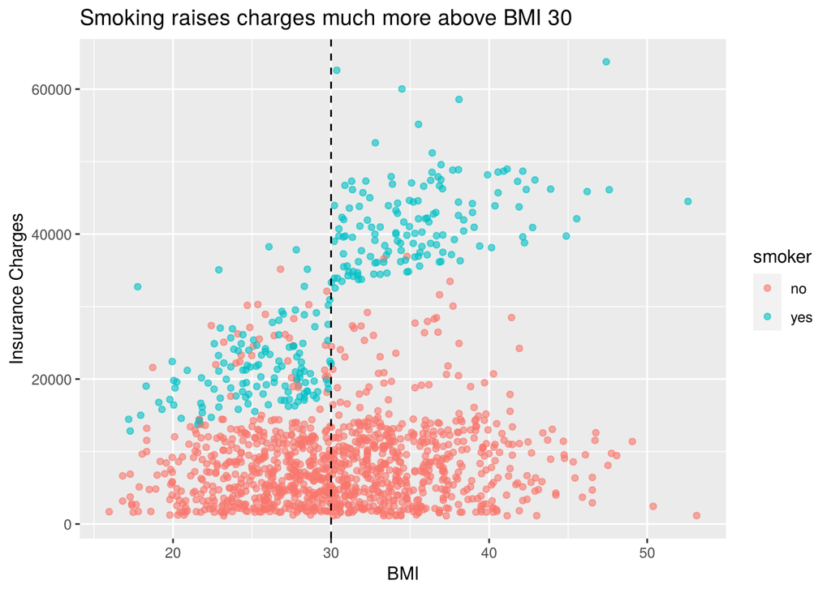

```r
ggplot(data, aes(x = bmi, y = charges, colour = smoker)) +
  geom_point(alpha = 0.6) +
  geom_vline(xintercept = 30, linetype = "dashed") +
  labs(title = "Smoking raises charges much more above BMI 30", x = "BMI", y = "Insurance Charges")
```

Adding an obesity indicator, its interaction with smoking, and a squared age term:

```r
data2$obese <- data2$bmi >= 30
model_interaction <- lm(charges ~ age + I(age^2) + children + bmi + smoker * obese + sex + region, data = data2)
summary(model_interaction)
```

```
##
## Call:
## lm(formula = charges ~ age + I(age^2) + children + bmi + smoker *
##     obese + sex + region, data = data2)
##
## Residuals:
##      Min       1Q   Median       3Q      Max
## -17296.4  -1656.0  -1263.3   -722.1  24160.2
##
## Coefficients:
##                       Estimate Std. Error t value Pr(>|t|)
## (Intercept)           134.2509  1362.7511   0.099 0.921539
## age                   -32.6851    59.8242  -0.546 0.584915
## I(age^2)                3.7316     0.7463   5.000 6.50e-07 ***
## children              678.5612   105.8831   6.409 2.04e-10 ***
## bmi                   120.0196    34.2660   3.503 0.000476 ***
## smokeryes           13404.6866   439.9491  30.469  < 2e-16 ***
## obeseTRUE           -1000.1403   422.8402  -2.365 0.018159 *
## sexmale              -496.8245   244.3659  -2.033 0.042240 *
## regionnorthwest      -279.2038   349.2746  -0.799 0.424212
## regionsoutheast      -828.5467   351.6352  -2.356 0.018604 *
## regionsouthwest     -1222.6437   350.5285  -3.488 0.000503 ***
## smokeryes:obeseTRUE 19810.7533   604.6567  32.764  < 2e-16 ***
## ---
## Signif. codes:  0 '***' 0.001 '**' 0.01 '*' 0.05 '.' 0.1 ' ' 1
##
## Residual standard error: 4445 on 1326 degrees of freedom
## Multiple R-squared:  0.8664, Adjusted R-squared:  0.8653
## F-statistic: 781.7 on 11 and 1326 DF,  p-value: < 2.2e-16
```

```r
c(original = summary(model)$adj.r.squared, with_interaction = summary(model_interaction)$adj.r.squared)
```

```
##         original with_interaction
##        0.7494136        0.8652861
```

Adjusted R-squared rises from about 0.75 to about 0.87. The `smokeryes:obeseTRUE` estimate is the extra charge for smokers who are also obese, roughly 20,000 on top of the smoking effect.

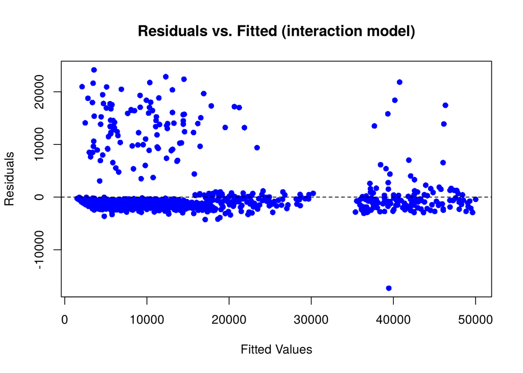

```r
plot(fitted(model_interaction), residuals(model_interaction), col = "blue", pch = 16,
     main = "Residuals vs. Fitted (interaction model)", xlab = "Fitted Values", ylab = "Residuals")
abline(h = 0, lty = 2)
```

Most residuals now sit in one band around zero. The points well above it are a minority of non-smokers whose charges are far higher than anything in the data explains, such as an illness the dataset doesn’t record. No transformation can fix that. It’s a limit of the available variables.

## Prediction of an Individual’s charges example

Here we will do a quick example with the interaction model, for a 34-year-old male smoker from the northeast with a BMI of 27 and no children:

```r
new_data <- data.frame(age = 34, sex = "male", bmi = 27, children = 0, smoker = "yes",
                       region = "northeast", obese = FALSE)
predict(model_interaction, newdata = new_data, interval = "prediction", level = 0.95)
```

```
##        fit      lwr     upr
## 1 19485.05 10710.59 28259.5
```

The model predicts charges of about 19,500, with a 95% prediction interval of roughly 10,700 to 28,300. The interval is wide because individual charges vary a lot even among similar people. As a check, smokers aged 30-38 with a BMI under 30 in the data have median charges of about 19,400:

```r
data %>% filter(smoker == "yes", bmi < 30, age >= 30, age <= 38) %>% summarise(n = n(), median_charges = median(charges))
```

| n | median_charges |
| --- | --- |
| 24 | 19356.18 |

(An earlier version predicted from the robust model on the log scale and reported `exp()` of the prediction as the expected charge. That has two problems. The model was fitted to log(charges + 1), so the back-transform is `exp(prediction) - 1`. And exponentiating a predicted log value gives roughly the median charge, not the mean. `predict()` also doesn’t produce valid prediction intervals for `rlm` models.)

```r
# Check for missing/infinite values in 'age' and 'charges'
any(!is.finite(data2$age))
```

```
## [1] FALSE
```

```r
any(!is.finite(data2$charges))
```

```
## [1] FALSE
```

## Interactive histogram

This app needs a live R session: run this chunk in RStudio. It is not evaluated in the static HTML.

```r
library(shiny)
library(dplyr)




ui <- fluidPage(
  titlePanel("Interactive Histogram"),
  sidebarLayout(
    sidebarPanel(
      selectInput("variable", "Choose Variable:",
                  choices = c("age", "bmi"),
                  selected = "age"),
      # The range slider is rebuilt for whichever variable is selected
      uiOutput("range_slider")
    ),
    mainPanel(
      plotOutput("histogram")
    )
  )
)


server <- function(input, output) {
  # The slider's limits follow the selected variable (age 18-64, BMI about 16-53).
  # Before, the slider always used age limits, so choosing BMI filtered on age-sized numbers.
  output$range_slider <- renderUI({
    values <- data[[input$variable]]
    sliderInput("range", "Select Range:",
                min = floor(min(values)), max = ceiling(max(values)),
                value = c(floor(min(values)), ceiling(max(values))), step = 1)
  })

  # Reactive expression to filter data based on user inputs
  filtered_data <- reactive({
    req(input$range)
    data %>%
      filter(get(input$variable) >= input$range[1],
             get(input$variable) <= input$range[2])
  })


  output$histogram <- renderPlot({
    if (length(unique(filtered_data()$charges)) > 1) {
      hist(filtered_data()$charges, main = "Distribution of Charges",
           xlab = "Charges", col = "lightblue", border = "black")
    } else {
      plot(1, type = "n", axes = FALSE, xlab = "", ylab = "")
      text(1, 1, "Not enough data for a histogram.", cex = 1.5, col = "red")
    }
  })
}


shinyApp(ui = ui, server = server)
```

[output not shown]